# Manne Research Institute COVID-19 Response

April 12, 2020

[figure not shown]

# COVID-19 Survey

[figure not shown]

## Introduction

In response to the COVID-19 pandemic, the Stanley Manne Children’s Research Institute has conducted a survey of expertise and scientific interest in the problem among our scientists. The survey has the following central goals:

- Identify existing expertise relevant to COVID-19 including pre-clinical, clinical, behavioral, population health, and bioethical areas.
- Identify specific prior expertise in coronaviruses.
- Learn of existing collaborative groups around COVID-19.
- Find opportunities to connect interested scientists into existing and new collaborative groups.
- Connect interested scientists into the Feinberg School of Medicine and NUCATS efforts around COVID-19 research.

This document serves to summarize data from the survey that can be disseminated to start new conversations and collaborations.

## The Survey Data

A survey was distributed to Manne Research Institute investigators on Tuesday, 4/7/2020 and first closed on Friday, 4/10/2020. We received 37 responses.

### Expertise and interest in Coronaviruses and COVID-19

The survey asked investigators to identify themselves, their clinical and scientific expertise including specific expertise with COVID-19, and their interest in collaborating on COVID-19-related research.

The investigators (see the end for the full list of names) have a range of ranks and clinical affiliations.

|  | Name | Clinical.expertise.unified |
| --- | --- | --- |
| 1 | Aaruni Khanolkar | clinical immunology |
| 2 | Adam Becker | non-clinical |
| 3 | Anne Rowley | infectious diseases |
| 4 | Bonnie Essner | psychology |
| 5 | Bria Coates | intensive care |
| 6 | Daniel Robinson | neonatology |
| 7 | Elizabeth Alpern | emergency medicine |
| 8 | Hiroyuki Hirai | non-clinical |
| 9 | Jacek Topczewski | non-clinical |
| 10 | Jeffery A. Goldstein | gastroenterology |

[output cut: 27 more lines]

Survey respondants provided their names and positions at Northwestern or at Lurie Children’s. A number of different ranks and areas of clinical expertise were represented in the survey.

|  | investigators (N = 37) |
| --- | --- |
| **Title** |  |
| Assistant Professor | 13 (35) |
| Associate Professor | 8 (22) |
| Professor | 9 (24) |
| Research Assistant Professor | 2 (5) |
| Research Associate Professor | 3 (8) |
| Research Professor | 1 (3) |
| Staff | 1 (3) |
| **Clinical.expertise.unified** |  |
| allegy and immunology | 1 (3) |
| clinical immunology | 1 (3) |
| emergency medicine | 4 (11) |
| gastroenterology | 2 (5) |
| infectious diseases | 6 (16) |
| intensive care | 3 (8) |
| neonatology | 4 (11) |
| neurology | 1 (3) |
| non-clinical | 11 (30) |
| psychology | 2 (5) |
| pulmonary | 1 (3) |
| surgery | 1 (3) |

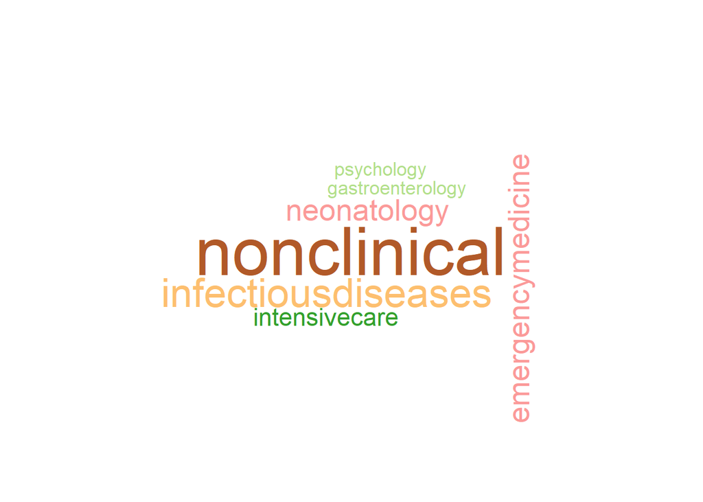

We also asked if any of our investigators have specific knowledge and experience around coronaviruses. This information is intended to anchor work and may help with collaborations to ensure the research foci have appropriate foci and relevance.

|  | . (N = 37) |
| --- | --- |
| **Do.you.have.specific.coronavirus.research.expertise.** |  |
| No | 32 (86) |
| Yes | 5 (14) |
| **Do.you.have.an.interest.in.collaborating.in.COVID.19.research.** |  |
| Yes | 37 (100) |

#### Individuals in the Manne Research Interest with Specific Coronavirus Expertise

We asked individuals to identify specific experience related to coronavirus scholarly work. A small set of individuals identified themselves as having some related experience.

| Name | Coronavirus Expertise |
| --- | --- |
| Aaruni Khanolkar | "I am a viral-immunologist by training and I have a long-standing interest in exploring the dynamics of host-pathogen interactions especially as they relate to exposure to viral pathogens through the … |
| Anne Rowley | We plan to evaluate the plasmablast response to SARS-CoV-2 infection, with the goals of identifying specific viral epitope targets of the antibody response, to inform diagnostic test development, pote… |
| Bria Coates | Research focus is on age-related differences in the innate immune response to viral respiratory infections. |
| Seema Shah | I am completing a project on the ethics of challenge studies that we have applied to the ethics of coronavirus challenge trials. |
| Leon G. Epstein, MD | "Prior experience with the HIV pandemic. Bioethics experience. I am currently the Chair of the American Academy of Neurology Ethics, Law and Humanities Committee" |

### Keywords for areas of interest in current COVID-19 work and areas that investigators hope to collaborate.

Respondants indicated keywords corresponding to their current areas of COVID-19 research and, in cases where applicable, to areas where they would like to participate and collaborate on COVID-19 research.

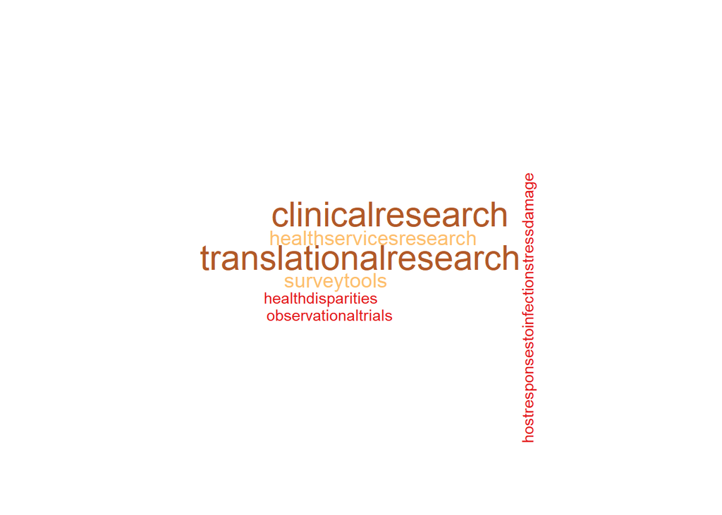

We also asked respondants to indicate areas of research of potential participation and collaboration based on their interests. The higher word density demonstrates the common interest in participating in a wide number of areas.

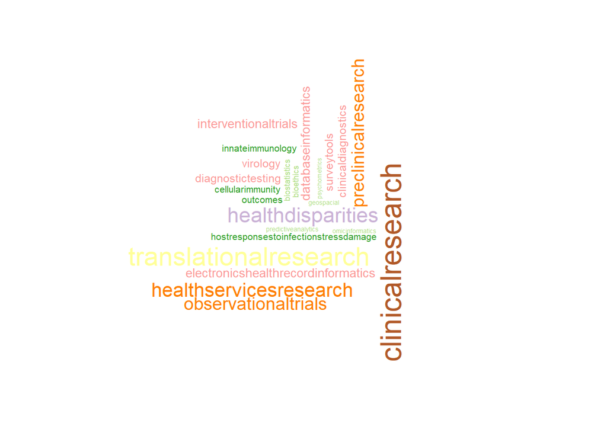